# SN_02_DOA_RECIP_ADDR_CNTR

Recipient country · Code report

## Overview

**Description**

Foreign Address - Country

**Table**

`SN-P02-T01-DISPOSITION-OF-ASSETS` (many)

**Location code**

`SCHED-N-PART-02-LINE-01-COL-F`

**Family**

`SCHED-N-PART-02-LINE-01-COL-F` · siblings: SN_02_DOA_RECIP_ADDR_CITY, SN_02_DOA_RECIP_ADDR_L1, SN_02_DOA_RECIP_ADDR_L2, SN_02_DOA_RECIP_ADDR_STATE, SN_02_DOA_RECIP_ADDR_ZIP, SN_02_DOA_RECIP_NAME_ORG_L1

**Data type**

text (xsd: CountryType)

**Scope**

PZ

**Status**

unreviewed

4

xpaths mapped (3 observed)

238

filings with a value

2009–2024

tax years observed

3

open flags (0 errors)

## Flags

| Severity | Flag | Xpath | Detail |
| --- | --- | --- | --- |
| ⓘ info | `MANY_NOT_REPEATING` | IRS990ScheduleN/DispositionOfAssetsDetail/ForeignAddress/CountryCd | many-to-one table, but 59% of values sit in no repeating element |
| ⓘ info | `MANY_NOT_REPEATING` | IRS990ScheduleN/DispositionTable/AddressForeign/Country | many-to-one table, but 53% of values sit in no repeating element |
| ⓘ info | `UNOBSERVED` | IRS990ScheduleN/Form990ScheduleNPartII/DispositionTable/AddressForeign/Country | never observed in TY2009-2024 filings |

## Xpaths

All mapped xpaths (under /Return/ReturnData or /Return/ReturnHeader), oldest first. Charts label each series by its xpath.

| Xpath | Form | Chart label | First year | Last year | Versions | Filings | Repeats in |
| --- | --- | --- | --- | --- | --- | --- | --- |
| IRS990ScheduleN/DispositionTable/AddressForeign/Country | Sched N | same | 2009 | 2012 | 9 | 38 | 34.2% |
| IRS990ScheduleN/DispositionOfAssetsDetail/ForeignAddress/Country | Sched N | …cheduleN/DispositionOfAssetsDetail/ForeignAddress/Country | 2013 | 2013 | 3 | 15 | 40.0% |
| IRS990ScheduleN/DispositionOfAssetsDetail/ForeignAddress/CountryCd | Sched N | …eduleN/DispositionOfAssetsDetail/ForeignAddress/CountryCd | 2014 | 2024 | 28 | 185 | 32.4% |
| IRS990ScheduleN/Form990ScheduleNPartII/DispositionTable/AddressForeign/Country | Sched N | …90ScheduleNPartII/DispositionTable/AddressForeign/Country |  |  |  | 0 |  |

## Coverage

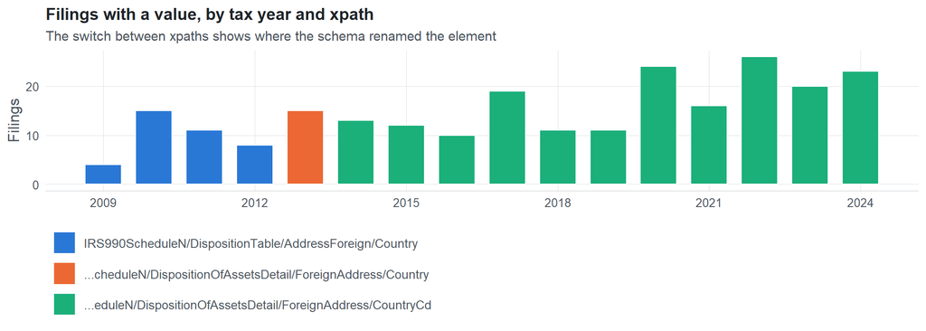

**Table view**

Table view: filings by tax year and series

| Tax year | IRS990ScheduleN/DispositionTable/AddressForeign/Country | …cheduleN/DispositionOfAssetsDetail/ForeignAddress/Country | …eduleN/DispositionOfAssetsDetail/ForeignAddress/CountryCd |
| --- | --- | --- | --- |
| 2009 | 4 | 0 | 0 |
| 2010 | 15 | 0 | 0 |
| 2011 | 11 | 0 | 0 |
| 2012 | 8 | 0 | 0 |
| 2013 | 0 | 15 | 0 |
| 2014 | 0 | 0 | 13 |
| 2015 | 0 | 0 | 12 |
| 2016 | 0 | 0 | 10 |
| 2017 | 0 | 0 | 19 |
| 2018 | 0 | 0 | 11 |
| 2019 | 0 | 0 | 11 |
| 2020 | 0 | 0 | 24 |
| 2021 | 0 | 0 | 16 |
| 2022 | 0 | 0 | 26 |
| 2023 | 0 | 0 | 20 |
| 2024 | 0 | 0 | 23 |

[figure not shown]

**Table view**

Table view: fill rate

| Tax year | Return type | Filings | All filings | Fill rate |
| --- | --- | --- | --- | --- |
| 2009 | Form 990 | 4 | 33,311 | 0.01% |
| 2010 | Form 990 | 13 | 123,025 | 0.01% |
| 2010 | Form 990-EZ | 2 | 63,326 | 0.00% |
| 2011 | Form 990 | 10 | 159,504 | 0.01% |
| 2011 | Form 990-EZ | 1 | 82,048 | 0.00% |
| 2012 | Form 990 | 6 | 179,688 | 0.00% |
| 2012 | Form 990-EZ | 2 | 93,750 | 0.00% |
| 2013 | Form 990 | 12 | 198,855 | 0.01% |
| 2013 | Form 990-EZ | 3 | 104,375 | 0.00% |
| 2014 | Form 990 | 12 | 218,619 | 0.01% |
| 2014 | Form 990-EZ | 1 | 116,417 | 0.00% |
| 2015 | Form 990 | 10 | 233,519 | 0.00% |
| 2015 | Form 990-EZ | 2 | 124,894 | 0.00% |
| 2016 | Form 990 | 6 | 243,903 | 0.00% |
| 2016 | Form 990-EZ | 4 | 130,484 | 0.00% |
| 2017 | Form 990 | 15 | 261,612 | 0.01% |
| 2017 | Form 990-EZ | 4 | 139,144 | 0.00% |
| 2018 | Form 990 | 9 | 271,442 | 0.00% |
| 2018 | Form 990-EZ | 2 | 149,384 | 0.00% |
| 2019 | Form 990 | 9 | 283,694 | 0.00% |
| 2019 | Form 990-EZ | 2 | 152,622 | 0.00% |
| 2020 | Form 990 | 18 | 320,342 | 0.01% |
| 2020 | Form 990-EZ | 6 | 169,864 | 0.00% |
| 2021 | Form 990 | 12 | 336,480 | 0.00% |
| 2021 | Form 990-EZ | 4 | 202,724 | 0.00% |
| 2022 | Form 990 | 21 | 349,055 | 0.01% |
| 2022 | Form 990-EZ | 5 | 206,130 | 0.00% |
| 2023 | Form 990 | 16 | 354,768 | 0.00% |
| 2023 | Form 990-EZ | 4 | 206,379 | 0.00% |
| 2024 | Form 990 | 21 | 277,298 | 0.01% |
| 2024 | Form 990-EZ | 2 | 178,867 | 0.00% |

## Repeating groups

Table cardinality in the concordance: **many**. 3 of 3 observed xpaths repeat within a filing.

Repeating element each xpath was observed in (from the raw indexed xpath)

| Xpath | Repeating element | Filings (summed over years) |
| --- | --- | --- |
| IRS990ScheduleN/DispositionTable/AddressForeign/Country | (none) | 20 |
| IRS990ScheduleN/DispositionTable/AddressForeign/Country | IRS990ScheduleN/DispositionTable | 18 |
| IRS990ScheduleN/DispositionOfAssetsDetail/ForeignAddress/Country | (none) | 7 |
| IRS990ScheduleN/DispositionOfAssetsDetail/ForeignAddress/Country | IRS990ScheduleN/DispositionOfAssetsDetail | 8 |
| IRS990ScheduleN/DispositionOfAssetsDetail/ForeignAddress/CountryCd | (none) | 110 |
| IRS990ScheduleN/DispositionOfAssetsDetail/ForeignAddress/CountryCd | IRS990ScheduleN/DispositionOfAssetsDetail | 75 |

## Values

| Result | Check | Detail |
| --- | --- | --- |
| ✓ pass | Small code list | up to 17 distinct values per xpath and year |
| ✓ pass | Codes share one format | 100% have the shape AA |
| ✓ pass | Consistent letter case | 0.0% of values are lower case |

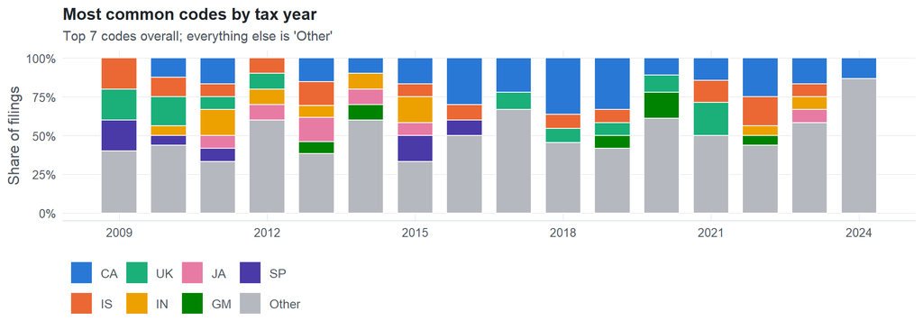

**Table view**

Table view: filings by code and tax year

| tax_year | CA | IS | UK | IN | JA | GM | SP | Other |
| --- | --- | --- | --- | --- | --- | --- | --- | --- |
| 2009 | 0 | 1 | 1 | 0 | 0 | 0 | 1 | 2 |
| 2010 | 2 | 2 | 3 | 1 | 0 | 0 | 1 | 7 |
| 2011 | 2 | 1 | 1 | 2 | 1 | 0 | 1 | 4 |
| 2012 | 0 | 1 | 1 | 1 | 1 | 0 | 0 | 6 |
| 2013 | 2 | 2 | 0 | 1 | 2 | 1 | 0 | 5 |
| 2014 | 1 | 0 | 0 | 1 | 1 | 1 | 0 | 6 |
| 2015 | 2 | 1 | 0 | 2 | 1 | 0 | 2 | 4 |
| 2016 | 3 | 1 | 0 | 0 | 0 | 0 | 1 | 5 |
| 2017 | 4 | 0 | 2 | 0 | 0 | 0 | 0 | 12 |
| 2018 | 4 | 1 | 1 | 0 | 0 | 0 | 0 | 5 |
| 2019 | 4 | 1 | 1 | 0 | 0 | 1 | 0 | 5 |
| 2020 | 2 | 0 | 2 | 0 | 0 | 3 | 0 | 11 |
| 2021 | 2 | 2 | 3 | 0 | 0 | 0 | 0 | 7 |
| 2022 | 4 | 3 | 0 | 1 | 0 | 1 | 0 | 7 |
| 2023 | 2 | 1 | 0 | 1 | 1 | 0 | 0 | 7 |
| 2024 | 2 | 0 | 0 | 0 | 0 | 0 | 0 | 13 |

Code frequencies (all xpaths, all years)

| Code | Filings | Share |
| --- | --- | --- |
| CA | 36 | 17.6% |
| IS | 17 | 8.3% |
| UK | 15 | 7.4% |
| IN | 10 | 4.9% |
| JA | 7 | 3.4% |
| GM | 7 | 3.4% |
| SP | 6 | 2.9% |
| NL | 6 | 2.9% |
| BF | 5 | 2.5% |
| HA | 5 | 2.5% |
| SF | 5 | 2.5% |
| FR | 5 | 2.5% |
| HK | 5 | 2.5% |
| CJ | 5 | 2.5% |
| UG | 4 | 2.0% |
| GT | 4 | 2.0% |
| RW | 3 | 1.5% |
| NU | 3 | 1.5% |
| AS | 3 | 1.5% |
| CG | 3 | 1.5% |
| LU | 3 | 1.5% |
| ID | 3 | 1.5% |
| AE | 2 | 1.0% |
| OD | 2 | 1.0% |
| PE | 2 | 1.0% |
| RS | 2 | 1.0% |
| EI | 2 | 1.0% |
| JM | 2 | 1.0% |
| MI | 2 | 1.0% |
| RO | 2 | 1.0% |

First rows shown.

## Examples

| Tax year | Return | Xpath | Organization | Value | Source |
| --- | --- | --- | --- | --- | --- |
| 2024 | 990 | IRS990ScheduleN/DispositionOfAssetsDetail/ForeignAddress/CountryCd | DECENTRALIZED PICTURES FOUNDATION INC | SZ | [XML](https://gt990datalake-rawdata.s3.amazonaws.com/EfileData/XmlFiles/202543219349313599_public.xml) |
| 2023 | 990 | IRS990ScheduleN/DispositionOfAssetsDetail/ForeignAddress/CountryCd | NEW GENERATION FOUNDATION INC | KZ | [XML](https://gt990datalake-rawdata.s3.amazonaws.com/EfileData/XmlFiles/202413209349327251_public.xml) |
| 2022 | 990 | IRS990ScheduleN/DispositionOfAssetsDetail/ForeignAddress/CountryCd | FUTURE OF LIFE INSTITUTE | SZ | [XML](https://gt990datalake-rawdata.s3.amazonaws.com/EfileData/XmlFiles/202510309349301606_public.xml) |
| 2021 | 990 | IRS990ScheduleN/DispositionOfAssetsDetail/ForeignAddress/CountryCd | EDUCATIONAL CIRCLES OF HOPE INC | CM | [XML](https://gt990datalake-rawdata.s3.amazonaws.com/EfileData/XmlFiles/202241309349305359_public.xml) |
| 2020 | 990 | IRS990ScheduleN/DispositionOfAssetsDetail/ForeignAddress/CountryCd | GREEN BUSINESS CERTIFICATION INC | NL | [XML](https://gt990datalake-rawdata.s3.amazonaws.com/EfileData/XmlFiles/202303469349300405_public.xml) |
| 2019 | 990 | IRS990ScheduleN/DispositionOfAssetsDetail/ForeignAddress/CountryCd | AMERICAN PATRONS OF THE PINAKOTHEK TRUST | GM | [XML](https://gt990datalake-rawdata.s3.amazonaws.com/EfileData/XmlFiles/202132549349300403_public.xml) |
| 2018 | 990 | IRS990ScheduleN/DispositionOfAssetsDetail/ForeignAddress/CountryCd | CANADIAN REVIVAL FELLOWSHIP | CA | [XML](https://gt990datalake-rawdata.s3.amazonaws.com/EfileData/XmlFiles/201941359349306129_public.xml) |
| 2017 | 990 | IRS990ScheduleN/DispositionOfAssetsDetail/ForeignAddress/CountryCd | ISRAAID US GLOBAL HUMANITARIAN ASSISTANCE INC | IS | [XML](https://gt990datalake-rawdata.s3.amazonaws.com/EfileData/XmlFiles/201803169349304140_public.xml) |
| 2016 | 990 | IRS990ScheduleN/DispositionOfAssetsDetail/ForeignAddress/CountryCd | RUMIE INITIATIVE INC | CA | [XML](https://gt990datalake-rawdata.s3.amazonaws.com/EfileData/XmlFiles/201733149349300303_public.xml) |
| 2015 | 990EZ | IRS990ScheduleN/DispositionOfAssetsDetail/ForeignAddress/CountryCd | FRIENDS OF APPLEBY COLLEGE UNITED | CA | [XML](https://gt990datalake-rawdata.s3.amazonaws.com/EfileData/XmlFiles/201631309349200818_public.xml) |
| 2014 | 990 | IRS990ScheduleN/DispositionOfAssetsDetail/ForeignAddress/CountryCd | ARCHAEOLOGICAL INSTITUTE OF AMERICA ST LOUIS SOCIETY | UK | [XML](https://gt990datalake-rawdata.s3.amazonaws.com/EfileData/XmlFiles/201512829349300121_public.xml) |
| 2013 | 990 | IRS990ScheduleN/DispositionOfAssetsDetail/ForeignAddress/Country | AMERICAN FRIENDS OF SDEI CHEMED | IS | [XML](https://gt990datalake-rawdata.s3.amazonaws.com/EfileData/XmlFiles/201412109349300331_public.xml) |

## Reviewer checklist

- The definition matches the form line and instructions for every xpath’s schema years.
- Every xpath pooled here measures the same thing on the 990 and 990-EZ (close enough for analysis).
- The coverage chart has no unexplained gaps or jumps between tax years.
- Each open flag is fixed, or accepted with a note in validation_log.csv.
- Every code is valid for the list the form uses (state, country, valuation method, …).
- The code list and its meaning did not change across schema versions.
- Codes are stored as text, so values like leading zeros are preserved.

Record the review as a row in `inst/extdata/src/validation_log.csv` (variable_name, reviewer, date, status, note). Evidence built 2026-09-23 17:09:04 MST from the ef2 DuckDB builds, TY2009–2024.